# CS 422 Section 01

Saptarshi Chatterjee (cwid - 20413922)

### 2.1 Problem 1: K-means clustering

```r
#Load libraries
library(factoextra)
library(cluster)
options("digits"=3)
rm(list=ls())
```

```r
# Load the Diabetes dataset and set seed
setwd("~/Desktop/Assignments&Coursework/422/Assignment3/")
set.seed(1122)
mamal <- read.csv("file19.csv", header=T, sep=",")
dim(mamal)
```

```
[1] 66  9
```

#### (a) Data cleanup

##### (i) Think of what attributes, if any, you may want to omit from the dataset when you do the clustering. Indicate all of the attributes you removed before doing the clustering.

> I’ll remove Atrribute “Name” and make it a Rowname. Because it’s a non numeric nominal attribute.

```r
rownames(mamal) <- mamal[,1]
mamal <- mamal [ , -1]
```

##### (ii) Does the data need to be standardized?

> Yes “C” and “c” has values in the range of 0-1 where as other attributes have values in the range of 0-5 . So scaling should give us better resuklt.

```r
mamal.scaled <- scale(mamal)
```

##### (iii) You will have to clean the data to remove multiple spaces and make the comma character the delimiter.Please make sure you include your cleaned dataset in the archive file you upload.

> Cleaned dtatset is included as file19.csv

#### (b) Clustering

##### (i) Determine how many clusters are needed by running the WSS or Silhouette graph. Plot the graph using fviz_nbclust().

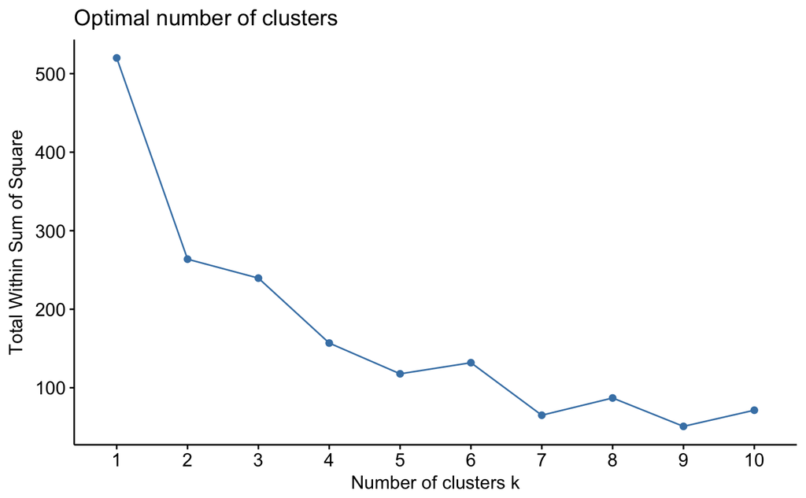

```r
fviz_nbclust(mamal.scaled, kmeans, method="wss")
```

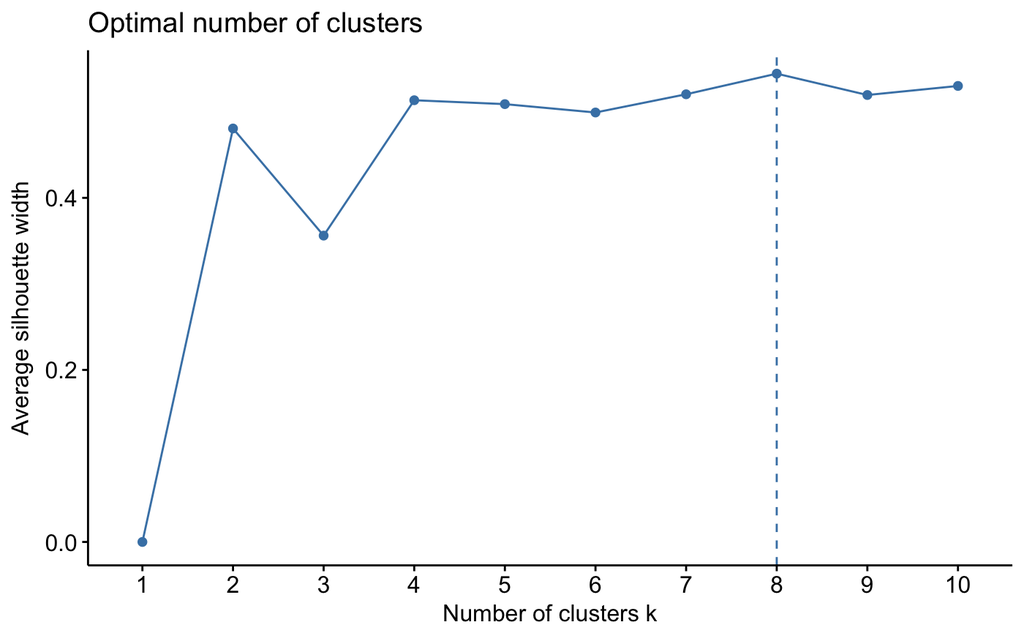

```r
fviz_nbclust(mamal.scaled, kmeans, method="silhouette")
```

Looks like beyond 7 cluster there is not reduce significant SS , and will lead to over fitting . So I’ll take k = 7

##### (ii) Once you have determined the number of clusters, run k-means clustering on the dataset to create that many clusters. Plot the clusters using fviz_cluster().

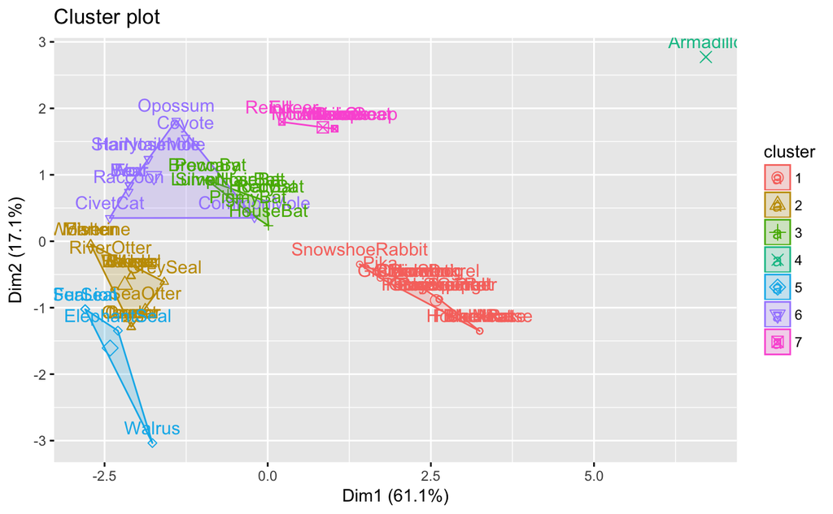

```r
k <- kmeans(mamal.scaled, centers=7, nstart=10)
fviz_cluster(k, data=mamal.scaled)
```

##### (iii) How many observations are in each cluster?

```r
print(k['size'])
```

```
$size
[1] 19 15  8  1  4 10  9
```

##### (iv) What is the total SSE of the clusters?

```r
print(k['totss'])
```

```
$totss
[1] 520
```

##### (v) What is the SSE of each cluster?

```r
print(k['withinss'])
```

```
$withinss
[1] 15.57 11.12  4.24  0.00  6.23 18.58  6.34
```

##### (vi) Perform an analysis of each cluster to determine how the mammals are grouped in each cluster, and whether that makes sense? For example, to get the indices of all animals in cluster 1, you would execute:

```r
for (clus in 1:7){
 print(which(k$cluster == clus))
 print("\n")
}
```

```
          Pika SnowshoeRabbit         Beaver         Marmot      Groundhog     PrairieDog GroundSquirrel       Chipmunk
            13             14             15             16             17             18             19             20
  GraySquirrel    FoxSquirrel   PocketGopher    KangarooRat        PackRat     FieldMouse        Muskrat       BlackRat
            21             22             23             24             25             26             27             28
    HouseMouse      Porcupine      GuineaPig
            29             30             31
[1] "\n"
    Marten     Fisher     Weasel       Mink     Ferrer  Wolverine     Badger      Skunk RiverOtter   SeaOtter     Jaguar
        38         39         40         41         42         43         44         45         46         47         48
    Ocelot     Cougar       Lynx   GreySeal
        49         50         51         55
[1] "\n"
     BrownBat SilverHairBat      PigmyBat      HouseBat        RedBat      HoaryBat   LumpNoseBat       Peccary
            5             6             7             8             9            10            11            57
[1] "\n"
Armadillo
       12
[1] "\n"
     FurSeal      SeaLion       Walrus ElephantSeal
          52           53           54           56
[1] "\n"
      Opossum Hairytailmole    CommonMole  StarNoseMole        Coyote          Wolf           Fox          Bear
            1             2             3             4            32            33            34            35
     CivetCat       Raccoon
           36            37
[1] "\n"
          Elk          Deer         Moose      Reindeer      Antelope         Bison  MountainGoat        MuskOx
           58            59            60            61            62            63            64            65
MountainSheep
           66
[1] "\n"
```

### 2.2 : Hierarchical clustering

```r
# Load the Diabetes dataset and set seed
setwd("~/Desktop/Assignments&Coursework/422/Assignment3/")
set.seed(1122)
lang.raw <- read.csv("language.csv", header=T, sep=",")
dim(lang.raw)
```

```
[1] 16 13
```

```r
rownames(lang.raw) <- lang.raw[,1]
lang.raw <- lang.raw [ , -1]
```

##### (a) Run hierarchical clustering on the dataset using factoextra::eclust() method. Run the clustering algorithm for three linkages: single, complete, and average. Plot the dendogram associated with each linkage using fviz_dend(). Make sure that the labels (country names) are visible at the leafs of the dendogram.

```r
lang <- lang.raw
hc.single <- eclust(lang, "hclust" , hc_method="single")
```

```
Clustering k = 1,2,..., K.max (= 10): .. done
Bootstrapping, b = 1,2,..., B (= 100)  [one "." per sample]:
.................................................. 50
.................................................. 100
```

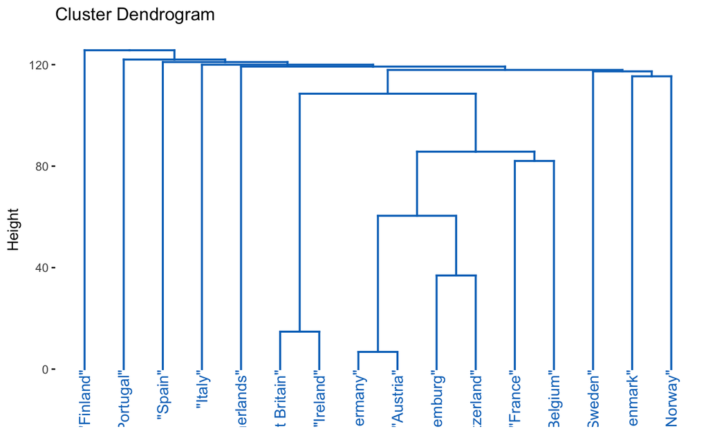

```r
fviz_dend(hc.single, palette="jco", as.ggplot=T)
```

```r
hc.complete <- eclust(lang, "hclust" , hc_method="complete")
```

```
Clustering k = 1,2,..., K.max (= 10): .. done
Bootstrapping, b = 1,2,..., B (= 100)  [one "." per sample]:
.................................................. 50
.................................................. 100
```

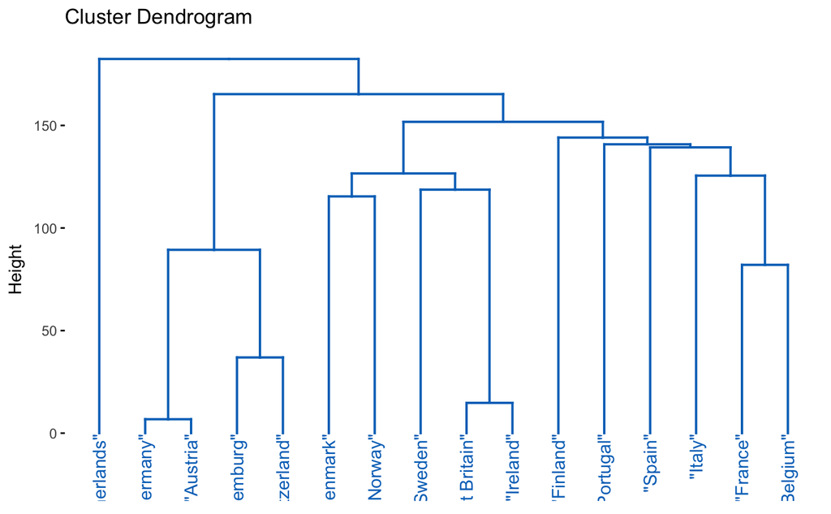

```r
fviz_dend(hc.complete,palette="jco", as.ggplot=T)
```

```r
hc.average <- eclust(lang, "hclust" , hc_method="average")
```

```
Clustering k = 1,2,..., K.max (= 10): .. done
Bootstrapping, b = 1,2,..., B (= 100)  [one "." per sample]:
.................................................. 50
.................................................. 100
```

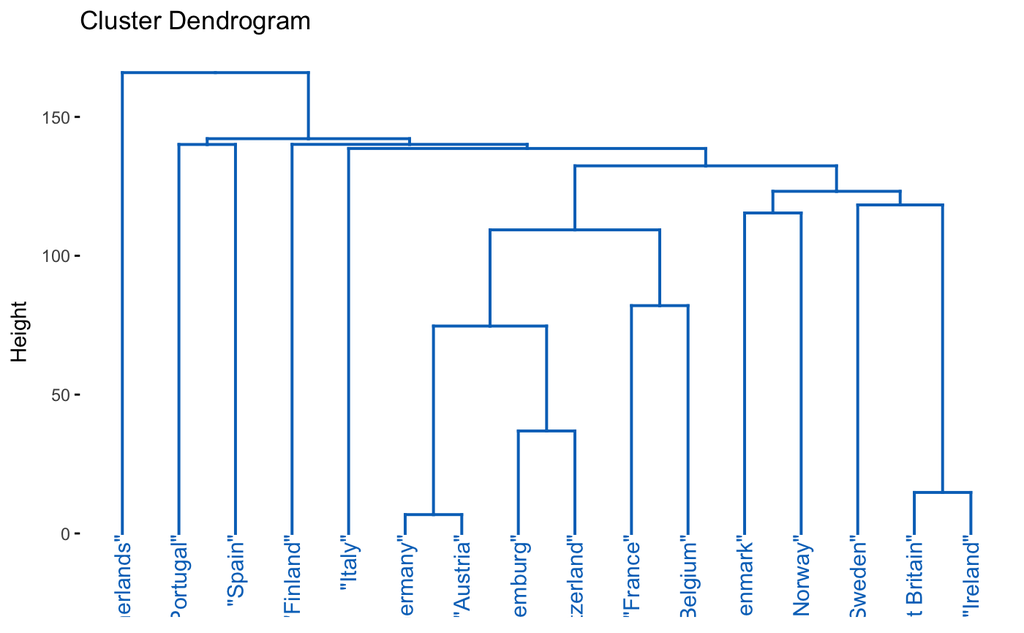

```r
fviz_dend(hc.average, palette="jco", as.ggplot=T)
```

##### (b) Examine each graph produced in (a) and understand the dendrogram. Notice which countries are clustered together as two-singleton clusters (i.e., two countries clustered together because they are very close to each other in the shared languages/s). For each linkage method, list all the two singleton clusters. For instance, {Great Britain, Ireland} form a two-singleton cluster since they share English as a common language.

> Result

For Single link -

{Great Britain, Ireland}, {West Germany , Austria}, {Luxemberg , Switzerland}, {Belgium, France}, {Denmark, Norway}

For Complete link -

{West Germany , Austria}, {Luxemberg , Switzerland}, {Denmark, Norway}, {Great Britain, Ireland}, {Belgium, France}

For Avg link -

{Portugal, Spain}, {West Germany , Austria}, {Luxemberg , Switzerland}, {Belgium, France}, {Denmark, Norway},{Great Britain, Ireland},

##### (c) Italy is clustered with a larger cluster in the single and average linkage, whereas in complete linkage it is clustered with a smaller cluster. Which linkage strategy do you think accurately reflects how Italy should be clustered? (Hint: Look at the raw data.) Justify your answer in 1-2 sentences.

> In my opinion , “complete link strategy” accurately reflects how Italy should be clustered. In Italy people majorly speakds Italian , and just 11% speaks french . Rest are negligible. In france every body speaks french , and 12% speaks Italian, So It makes sense to have Italy closer to France and Belgium cluster.

##### (d) Let’s pick a hierarchical cluster that we will call pure, and let’s define purity as the linkage strategy that produces the most two-singleton clusters. Of the linkage methods you examined in (b), which linkage method would be considered pure by our definition?

> Averae link is considered as pure as it has 6 two-singleton .{Portugal, Spain}, {West Germany , Austria}, {Luxemberg , Switzerland}, {Belgium, France}, {Denmark, Norway},{Great Britain, Ireland},

##### (e) Using the graph corresponding to the linkage method you chose in (d), at at a height of about 125, how many clusters would you have?

```r
clusters.125 <- cutree(hc.average, h=125)
sprintf("We will have %d Clusters", max(clusters.125))
```

```
[1] "We will have 7 Clusters"
```

##### (f) Now, using the number of clusters you picked in (e), re-run the hierarchical clustering using the three linkage modes again, except this time through, specify the number of clusters using the k parameter to factoextra::eclust(). Plot the dendogram associated with each linkage using fviz_dend(). Make sure that the labels (country names) are visible at the leafs of the dendogram.

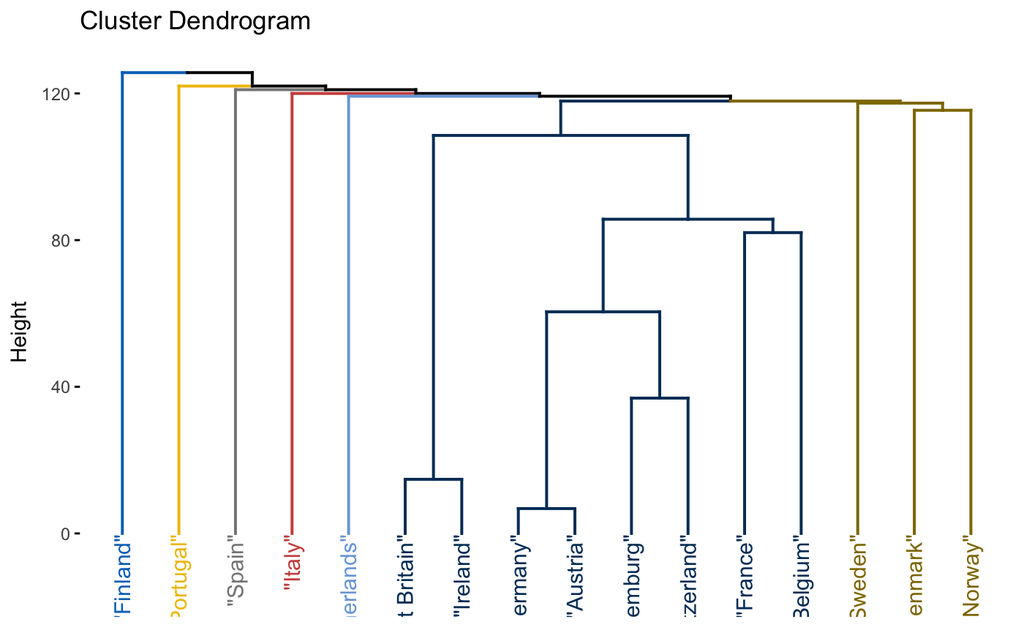

```r
hc.single <- eclust(lang, "hclust" , k = max(clusters.125),  hc_method="single")
fviz_dend(hc.single, palette="jco", as.ggplot=T)
```

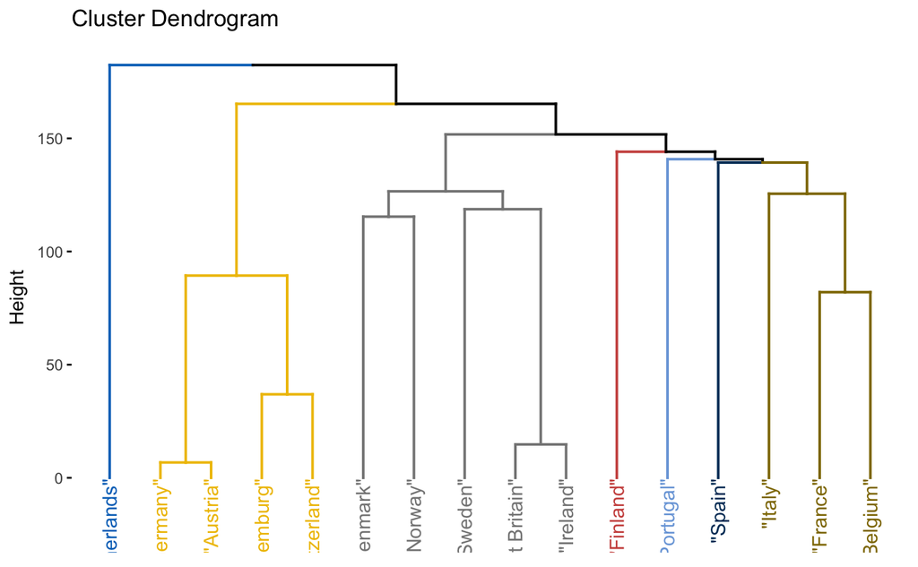

```r
hc.complete <- eclust(lang, "hclust", k = max(clusters.125), hc_method="complete")
fviz_dend(hc.complete,palette="jco", as.ggplot=T)
```

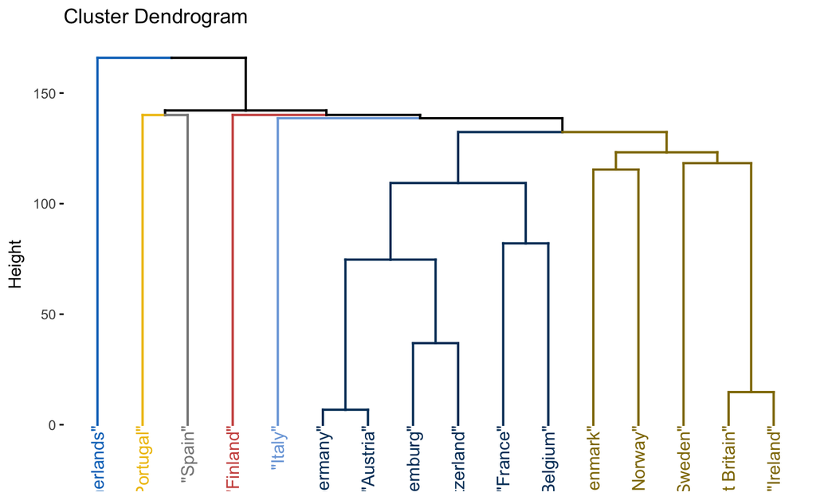

```r
hc.average <- eclust(lang, "hclust", k= max(clusters.125), hc_method="average")
fviz_dend(hc.average, palette="jco", as.ggplot=T)
```

##### (g) For each cluster obtained by the value of k used in (f), print the Dunn and Silhouette width using the fpc::cluster.stats() method.

```r
stats <- fpc::cluster.stats(dist(lang), cutree(hc.single, k=max(clusters.125)))
sprintf("For Single Link Dunn Index %f", stats['dunn'])
```

```
[1] "For Single Link Dunn Index 0.781301"
```

```r
sprintf("For Single Link Silwidth %f", stats['avg.silwidth'])
```

```
[1] "For Single Link Silwidth 0.121515"
```

```r
stats <- fpc::cluster.stats(dist(lang), cutree(hc.complete, k=max(clusters.125)))
sprintf("For Complete Link Dunn Index %f", stats['dunn'])
```

```
[1] "For Complete Link Dunn Index 0.676882"
```

```r
sprintf("For Complete Link Silwidth %f", stats['avg.silwidth'])
```

```
[1] "For Complete Link Silwidth 0.192231"
```

```r
stats <- fpc::cluster.stats(dist(lang), cutree(hc.average, k=max(clusters.125)))
sprintf("For Avg. Link Dunn Index %f", stats['dunn'])
```

```
[1] "For Avg. Link Dunn Index 0.807345"
```

```r
sprintf("For Avg. Link Silwidth %f", stats['avg.silwidth'])
```

```
[1] "For Avg. Link Silwidth 0.169825"
```

##### (h) From the three clusters in (g), which is the best cluster obtained if you consider the Dunn index only?

> Best cluster if we consider Dunn index is “Avg Link Dunn Index 0.807345”

##### (i) From the three clusters in (g), which is the best cluster obtained if you consider the Silhouette width only?

> Best cluster if we consider Silhouette width is “Complete Link Silwidth 0.192231”

#### 2.3 Problem 3: K-Means and PCA

##### (a) Perform PCA on the dataset and answer the following questions

```r
# Load the Diabetes dataset and set seed
setwd("~/Desktop/Assignments&Coursework/422/Assignment3/")
set.seed(1122)
options("digits"=3)
pulsar <- read.csv("HTRU_2.csv", header=T, sep=",")
pulsar <- pulsar
pr.out <- prcomp(scale(pulsar))
```

##### (i) How much cumulative variance is explained by the first two components?

```r
summary(pr.out)
```

```
Importance of components:
                         PC1   PC2    PC3    PC4    PC5    PC6    PC7     PC8     PC9
Standard deviation     2.175 1.482 0.9044 0.7103 0.5580 0.5079 0.3825 0.13199 0.12659
Proportion of Variance 0.526 0.244 0.0909 0.0561 0.0346 0.0287 0.0163 0.00194 0.00178
Cumulative Proportion  0.526 0.770 0.8607 0.9168 0.9514 0.9800 0.9963 0.99822 1.00000
```

> Explained varience is .770

##### (ii) Plot the first two principal components. Use a different color to represent the observations in the two classes.

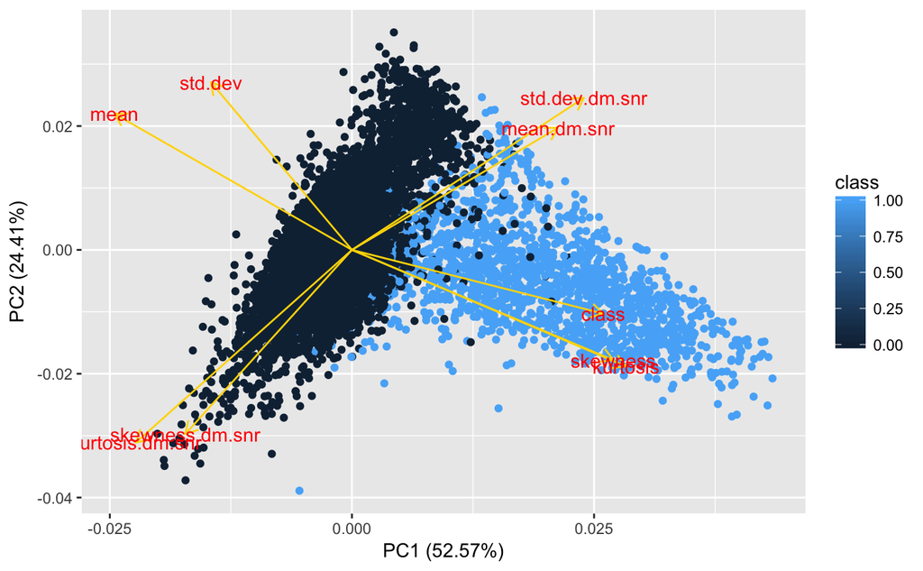

```r
library(ggfortify)
library(ggplot2)
autoplot(pr.out, data = pulsar, colour = "class", loadings = TRUE,loadings.colour = 'gold',
         loadings.label = TRUE)
```

##### (iii) Describe what you see with respect to the actual label of the HTRU2 dataset.

> Skewness and Kurtosis have eigen vector in same direction . This attributes are highly corelated. Same can be said about “skewness.dm.snr” and “kurtosis.dm.snr”

##### (b) We know that the HTRU2 dataset has two classes. We will now use K-means on the HTRU2 dataset.

##### (i) Perform K-means clustering on the dataset with k = 2. Plot the resulting clusters.

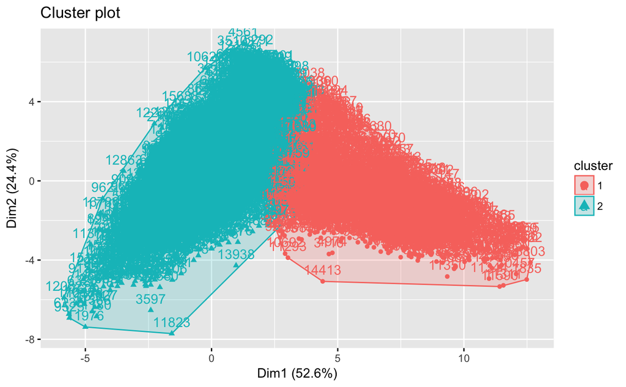

```r
k <- kmeans(scale(pulsar), centers=2, nstart=25)
fviz_cluster(k, data=pulsar)
```

##### (ii) Provide observations on the shape of the clusters you got in (b)(i) to the plot of the first two principal components in (a)(ii). If the clusters are are similar, why? If they are not, why?

> Clusters are similar . As PCA cluster is based on 2 most important variables that explain highest standard deviation . Where is Kmeans consider all the available factors. How ever if we run K means on only on dataset only having 2 principal component then the shape will be similar.

##### (iii) What is the distribution of the observations in each cluster?

```r
k$size
```

```
[1]  2596 15302
```

##### (iv) What is the distribution of the classes in the HTRU2 dataset?

```r
class1 <- sum(pulsar$class)
sprintf(" Class 1 have %d Obs , Class 0 have %d ", class1 , dim(pulsar)[1] - class1)
```

```
[1] " Class 1 have 1639 Obs , Class 0 have 16259 "
```

##### (vi) Let’s focus on the larger cluster. Get all of the observations that belong to this cluster. Then, state what is the distribution of the classes within this large cluster; i.e., how many observations in this large cluster belong to class 1 and how many belong to class 0?

```r
pulsarc1 <- pulsar[k$cluster==1,]
num1inLC <- sum(pulsarc1$class)
sprintf("Number of Obs belonging to class 1 in Large cluster is %d and Number of Obs belonging to class 0 in Large cluster is %d " , num1inLC, dim(pulsarc1)[1] - num1inLC)
```

[output not shown]

##### (vii) Based on the analysis above, which class (1 or 0) do you think the larger cluster represents?

> Larger cluster represents class 0.

##### (viii) How much variance is explained by the clustering?

```r
(k$tot.withinss / k$totss)
```

```
[1] 0.608
```

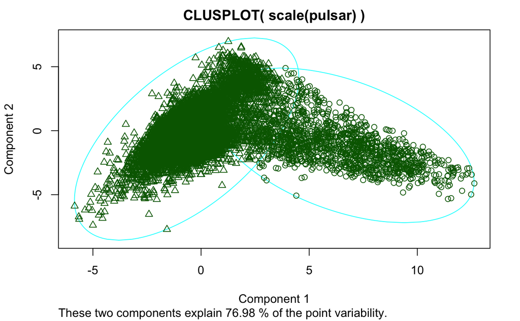

```r
clusplot(scale(pulsar), k$cluster)
```

##### (ix) What is the average Silhouette width of both the clusters?

```r
psl<- silhouette(k$cluster, dist(pulsar))
summary(psl)
```

[output not shown]

> Average Silhouette width of both the clusters 0.552 0.284

##### (x) What is the per cluster Silhouette width? Based on this, which cluster is good?

> The silhouette value is a measure of how similar an object is to its own cluster. So clearly cluster 1 has higher average silhouette widths so It’s better Cluster.

##### (c) Perform K-means on the result of the PCA you ran in (a). More specifically, perform K-means on the first two principal component score vectors (i.e., pca$x[, 1:2]). Use k = 2.

```r
k <- kmeans(pr.out$x[, 1:2], centers=2, nstart=25)
```

##### (i) Plot the clusters and comment on their shape with respect to the plots of a(ii) and b(i).

[figure not shown]

```r
fviz_cluster(k, data=pulsar)
```

##### (ii) What is the average Silhouette width of both the clusters?

```r
psl<- silhouette(k$cluster, dist(pulsar))
summary(psl)
```

```
Silhouette of 17898 units in 2 clusters from silhouette.default(x = k$cluster, dist = dist(pulsar)) :
 Cluster sizes and average silhouette widths:
 1363 16535
0.558 0.289
Individual silhouette widths:
   Min. 1st Qu.  Median    Mean 3rd Qu.    Max.
 -0.602   0.224   0.403   0.310   0.477   0.686
```

> average silhouette widths are 0.558 0.289

##### (iii) What is the per cluster Silhouette width? Based on this, which cluster is good?

> The silhouette value is a measure of how similar an object is to its own cluster. So clearly cluster 1 has higher average silhouette widths than cluster 2, so It’s better

##### (iv) How do the values of c(ii) and c(iii) compare with those of b(ix) and b(x), respectively?

> valuesb c(ii) and c(iii) (0.558 0.289 ) is a better cluster than b(ix) and b(x) (0.552 0.284). As the average silhouette widths of both the cluster is better for c(ii) and c(iii) .